# Personal Loan Campaign

Description Background and Context

AllLife Bank is a US bank that has a growing customer base. The majority of these customers are liability customers (depositors) with varying sizes of deposits. The number of customers who are also borrowers (asset customers) is quite small, and the bank is interested in expanding this base rapidly to bring in more loan business and in the process, earn more through the interest on loans. In particular, the management wants to explore ways of converting its liability customers to personal loan customers (while retaining them as depositors).

A campaign that the bank ran last year for liability customers showed a healthy conversion rate of over 9% success. This has encouraged the retail marketing department to devise campaigns with better target marketing to increase the success ratio.

You as a Data scientist at AllLife bank have to build a model that will help the marketing department to identify the potential customers who have a higher probability of purchasing the loan.

# Objective

1) To predict whether a liability customer will buy a personal loan or not. 2) Which variables are most significant. 3) Which segment of customers should be targeted more.

# Data Dictionary

- ID: Customer ID
- Age: Customer’s age in completed years
- Experience: #years of professional experience
- Income: Annual income of the customer (in thousand dollars)
- ZIP Code: Home Address ZIP code.
- Family: the Family size of the customer
- CCAvg: Average spending on credit cards per month (in thousand dollars)
- Education: Education Level. 1: Undergrad; 2: Graduate;3: Advanced/Professional
- Mortgage: Value of house mortgage if any. (in thousand dollars)
- Personal_Loan: Did this customer accept the personal loan offered in the last campaign?
- Securities_Account: Does the customer have securities account with the bank?
- CD_Account: Does the customer have a certificate of deposit (CD) account with the bank?
- Online: Do customers use internet banking facilities?
- CreditCard: Does the customer use a credit card issued by any other Bank (excluding All life Bank)?

```python
import pandas as pd
import numpy as np
from sklearn import metrics
import matplotlib.pyplot as plt
%matplotlib inline
import seaborn as sns
sns.set(color_codes=True)
from sklearn.model_selection import train_test_split
from sklearn.linear_model import LogisticRegression
from sklearn.tree import DecisionTreeClassifier
from sklearn import tree
from sklearn.model_selection import GridSearchCV
import pandas as pd
import numpy as np
pd.set_option("display.max_columns", None)
pd.set_option("display.max_rows", 200)

from sklearn.metrics import (
    f1_score,
    accuracy_score,
    recall_score,
    precision_score,
    confusion_matrix,
    precision_recall_curve,
    make_scorer,
)
```

```python
df=pd.read_csv("Loan_Modelling.csv")
```

```python
df.head()
```

|  | ID | Age | Experience | Income | ZIPCode | Family | CCAvg | Education | Mortgage | Personal_Loan | Securities_Account | CD_Account | Online | CreditCard |
| --- | --- | --- | --- | --- | --- | --- | --- | --- | --- | --- | --- | --- | --- | --- |
| 0 | 1 | 25 | 1 | 49 | 91107 | 4 | 1.6 | 1 | 0 | 0 | 1 | 0 | 0 | 0 |
| 1 | 2 | 45 | 19 | 34 | 90089 | 3 | 1.5 | 1 | 0 | 0 | 1 | 0 | 0 | 0 |
| 2 | 3 | 39 | 15 | 11 | 94720 | 1 | 1.0 | 1 | 0 | 0 | 0 | 0 | 0 | 0 |
| 3 | 4 | 35 | 9 | 100 | 94112 | 1 | 2.7 | 2 | 0 | 0 | 0 | 0 | 0 | 0 |
| 4 | 5 | 35 | 8 | 45 | 91330 | 4 | 1.0 | 2 | 0 | 0 | 0 | 0 | 0 | 1 |

```python
print(f"There are {df.shape[0]} rows and {df.shape[1]} columns")
```

```
There are 5000 rows and 14 columns
```

```python
df.isnull().sum() # there is no missing value
```

```
ID                    0
Age                   0
Experience            0
Income                0
ZIPCode               0
Family                0
CCAvg                 0
Education             0
Mortgage              0
Personal_Loan         0
Securities_Account    0
CD_Account            0
Online                0
CreditCard            0
dtype: int64
```

```python
df.duplicated().sum() #There is no duplicated rows
```

```
0
```

```python
df.dtypes # columns are int or float
```

```
ID                      int64
Age                     int64
Experience              int64
Income                  int64
ZIPCode                 int64
Family                  int64
CCAvg                 float64
Education               int64
Mortgage                int64
Personal_Loan           int64
Securities_Account      int64
CD_Account              int64
Online                  int64
CreditCard              int64
dtype: object
```

```python
df.describe().T
```

|  | count | mean | std | min | 25% | 50% | 75% | max |
| --- | --- | --- | --- | --- | --- | --- | --- | --- |
| ID | 5000.0 | 2500.500000 | 1443.520003 | 1.0 | 1250.75 | 2500.5 | 3750.25 | 5000.0 |
| Age | 5000.0 | 45.338400 | 11.463166 | 23.0 | 35.00 | 45.0 | 55.00 | 67.0 |
| Experience | 5000.0 | 20.104600 | 11.467954 | -3.0 | 10.00 | 20.0 | 30.00 | 43.0 |
| Income | 5000.0 | 73.774200 | 46.033729 | 8.0 | 39.00 | 64.0 | 98.00 | 224.0 |
| ZIPCode | 5000.0 | 93169.257000 | 1759.455086 | 90005.0 | 91911.00 | 93437.0 | 94608.00 | 96651.0 |
| Family | 5000.0 | 2.396400 | 1.147663 | 1.0 | 1.00 | 2.0 | 3.00 | 4.0 |
| CCAvg | 5000.0 | 1.937938 | 1.747659 | 0.0 | 0.70 | 1.5 | 2.50 | 10.0 |
| Education | 5000.0 | 1.881000 | 0.839869 | 1.0 | 1.00 | 2.0 | 3.00 | 3.0 |
| Mortgage | 5000.0 | 56.498800 | 101.713802 | 0.0 | 0.00 | 0.0 | 101.00 | 635.0 |
| Personal_Loan | 5000.0 | 0.096000 | 0.294621 | 0.0 | 0.00 | 0.0 | 0.00 | 1.0 |
| Securities_Account | 5000.0 | 0.104400 | 0.305809 | 0.0 | 0.00 | 0.0 | 0.00 | 1.0 |
| CD_Account | 5000.0 | 0.060400 | 0.238250 | 0.0 | 0.00 | 0.0 | 0.00 | 1.0 |
| Online | 5000.0 | 0.596800 | 0.490589 | 0.0 | 0.00 | 1.0 | 1.00 | 1.0 |
| CreditCard | 5000.0 | 0.294000 | 0.455637 | 0.0 | 0.00 | 0.0 | 1.00 | 1.0 |

```python
df["Experience"].value_counts() #there are some negative values
```

```
 32    154
 20    148
 9     147
 5     146
 23    144
 35    143
 25    142
 28    138
 18    137
 19    135
 26    134
 24    131
 3     129
 14    127
 16    127
```

[output cut: 33 more lines]

```python
df.ZIPCode.nunique()
```

```
467
```

```python
df.Mortgage.value_counts()
```

```
0      3462
98       17
103      16
119      16
83       16
       ...
541       1
509       1
505       1
485       1
577       1
Name: Mortgage, Length: 347, dtype: int64
```

```python
df.Education.value_counts()
```

```
1    2096
3    1501
2    1403
Name: Education, dtype: int64
```

```python
df.Family.value_counts()
```

```
1    1472
2    1296
4    1222
3    1010
Name: Family, dtype: int64
```

### Observation

1) All columns are numerical 2) Some values on the experience column have negative values; these values should be removed 3) No missing values and duplicated rows. 4) ID column should be dropped. 5) Securities_Account,CD_Account, Online,Personal_Loan, and CreditCard columns have two values(0 and 1)

```python
df1=df.copy()
```

```python
df1.drop(["ID"], axis=1, inplace=True)
```

```python
val=[-1,-2,-3]
df1=df1[df1.Experience.isin(val)==False]  #drop -1,-2,-3 years experiences
```

```python
df1.Experience.value_counts() #recheck the values on the experience column
```

```
32    154
20    148
9     147
5     146
23    144
35    143
25    142
28    138
18    137
19    135
26    134
24    131
3     129
16    127
14    127
```

[output cut: 30 more lines]

```python
df1[["ZIPCode","Education","Securities_Account","CD_Account","Personal_Loan", "Online","CreditCard","Family"]]=df1[["ZIPCode","Education","Personal_Loan", "Securities_Account","CD_Account", "Online","CreditCard","Family"]].astype('category')
```

```python
df1.dtypes
```

```
Age                      int64
Experience               int64
Income                   int64
ZIPCode               category
Family                category
CCAvg                  float64
Education             category
Mortgage                 int64
Personal_Loan         category
Securities_Account    category
CD_Account            category
Online                category
CreditCard            category
dtype: object
```

```python
df1["ZIPCode"].nunique() # There are 467 unique zipcodes. Convert the zipcodes to county,region, city, and state
```

```
467
```

```python
from uszipcode import SearchEngine, SimpleZipcode, ComprehensiveZipcode
search = SearchEngine()
def zip_values(x):
    values = search.by_zipcode(x)
    return values

values = df1['ZIPCode'].apply(zip_values)
```

```python
df1["county"]= values.dropna().apply(lambda x : x.county)
```

```python
df1["county"].unique() #there are some nan values
```

```
array(['Los Angeles County', 'Alameda County', 'San Francisco County',
       'San Diego County', 'Monterey County', 'Ventura County',
       'Santa Barbara County', 'Marin County', 'Santa Clara County',
       'Santa Cruz County', 'San Mateo County', 'Humboldt County',
       'Contra Costa County', 'Orange County', 'Sacramento County',
       'Yolo County', 'Placer County', 'San Bernardino County',
       'San Luis Obispo County', 'Riverside County', 'Kern County', nan,
       'Fresno County', 'Sonoma County', 'El Dorado County',
       'San Benito County', 'Butte County', 'Solano County',
       'Mendocino County', 'San Joaquin County', 'Imperial County',
       'Siskiyou County', 'Merced County', 'Trinity County',
       'Stanislaus County', 'Shasta County', 'Tuolumne County',
       'Napa County', 'Lake County'], dtype=object)
```

```python
df1.isnull().sum()
```

```
Age                    0
Experience             0
Income                 0
ZIPCode                0
Family                 0
CCAvg                  0
Education              0
Mortgage               0
Personal_Loan          0
Securities_Account     0
CD_Account             0
Online                 0
CreditCard             0
county                33
dtype: int64
```

```python
df1.dropna(inplace=True) #drop missing values
```

```python
df1.isnull().sum() #no missing values
```

```
Age                   0
Experience            0
Income                0
ZIPCode               0
Family                0
CCAvg                 0
Education             0
Mortgage              0
Personal_Loan         0
Securities_Account    0
CD_Account            0
Online                0
CreditCard            0
county                0
dtype: int64
```

```python
df1.county.nunique() ##there is 38 unique county; need to convert the counties to regions. There is no region data point at the website (https://pypi.org/project/uszipcode/), so the counties list is created using https://www.calbhbc.org/region-map-and-listing.html
```

```
38
```

```python
counties = {
 'Los Angeles County':'LOS ANGELES',
 'Alameda County':'BAY',
 'San Francisco County':'BAY',
 'San Diego County':'SOUTHERN',
 'Monterey County':'BAY',
 'Ventura County':'SOUTHERN',
 'Santa Barbara County':'SOUTHERN',
 'Marin County':'BAY',
 'Santa Clara County':'BAY',
 'Santa Cruz County':'BAY',
 'San Mateo County':'BAY',
 'Humboldt County':'SUPERIOR',
 'Contra Costa County':'BAY',
 'Orange County':'SOUTHERN',
 'Sacramento County':'CENTRAL',
 'Yolo County':'CENTRAL',
 'Placer County':'CENTRAL',
 'San Bernardino County':'SOUTHERN',
 'San Luis Obispo County':'SOUTHERN',
 'Riverside County':'SOUTHERN',
 'Kern County':'SOUTHERN',
 'Fresno County':'CENTRAL',
 'Sonoma County':'BAY',
 'El Dorado County':'CENTRAL',
 'San Benito County':'BAY',
 'Butte County':'SUPERIOR',
 'Solano County':'BAY',
 'Mendocino County':'SUPERIOR',
 'San Joaquin County':'CENTRAL',
 'Imperial County':'SOUTHERN',
 'Siskiyou County':'SUPERIOR',
 'Merced County':'CENTRAL',
 'Trinity County':'SUPERIOR',
 'Stanislaus County':'CENTRAL',
 'Shasta County':'SUPERIOR',
 'Tuolumne County':'CENTRAL',
 'Napa County':'BAY',
 'Lake County':'SUPERIOR'
}
```

```python
df1["Region"]=df1["county"].map(counties)
```

```python
df1.Region.unique() # check unique areas
```

```
array(['LOS ANGELES', 'BAY', 'SOUTHERN', 'SUPERIOR', 'CENTRAL'],
      dtype=object)
```

```python
df1.head()
```

|  | Age | Experience | Income | ZIPCode | Family | CCAvg | Education | Mortgage | Personal_Loan | Securities_Account | CD_Account | Online | CreditCard | county | Region |
| --- | --- | --- | --- | --- | --- | --- | --- | --- | --- | --- | --- | --- | --- | --- | --- |
| 0 | 25 | 1 | 49 | 91107 | 4 | 1.6 | 1 | 0 | 0 | 0 | 1 | 0 | 0 | Los Angeles County | LOS ANGELES |
| 1 | 45 | 19 | 34 | 90089 | 3 | 1.5 | 1 | 0 | 0 | 0 | 1 | 0 | 0 | Los Angeles County | LOS ANGELES |
| 2 | 39 | 15 | 11 | 94720 | 1 | 1.0 | 1 | 0 | 0 | 0 | 0 | 0 | 0 | Alameda County | BAY |
| 3 | 35 | 9 | 100 | 94112 | 1 | 2.7 | 2 | 0 | 0 | 0 | 0 | 0 | 0 | San Francisco County | BAY |
| 4 | 35 | 8 | 45 | 91330 | 4 | 1.0 | 2 | 0 | 0 | 0 | 0 | 0 | 1 | Los Angeles County | LOS ANGELES |

```python
df1["city"]= values.dropna().apply(lambda x : x.major_city)
```

```python
df1["city"].nunique() #there are 244 cities. City column should be dropped
```

```
244
```

```python
df1["state"]= values.dropna().apply(lambda x : x.state)
```

```python
df1["state"].nunique()
```

```
1
```

```python
df1["state"].unique() # Only one state, CA, the state column should be dropped
```

```
array(['CA'], dtype=object)
```

```python
df1.head()
```

|  | Age | Experience | Income | ZIPCode | Family | CCAvg | Education | Mortgage | Personal_Loan | Securities_Account | CD_Account | Online | CreditCard | county | Region | city | state |
| --- | --- | --- | --- | --- | --- | --- | --- | --- | --- | --- | --- | --- | --- | --- | --- | --- | --- |
| 0 | 25 | 1 | 49 | 91107 | 4 | 1.6 | 1 | 0 | 0 | 0 | 1 | 0 | 0 | Los Angeles County | LOS ANGELES | Pasadena | CA |
| 1 | 45 | 19 | 34 | 90089 | 3 | 1.5 | 1 | 0 | 0 | 0 | 1 | 0 | 0 | Los Angeles County | LOS ANGELES | Los Angeles | CA |
| 2 | 39 | 15 | 11 | 94720 | 1 | 1.0 | 1 | 0 | 0 | 0 | 0 | 0 | 0 | Alameda County | BAY | Berkeley | CA |
| 3 | 35 | 9 | 100 | 94112 | 1 | 2.7 | 2 | 0 | 0 | 0 | 0 | 0 | 0 | San Francisco County | BAY | San Francisco | CA |
| 4 | 35 | 8 | 45 | 91330 | 4 | 1.0 | 2 | 0 | 0 | 0 | 0 | 0 | 1 | Los Angeles County | LOS ANGELES | Northridge | CA |

```python
df1.drop(["state","city","ZIPCode","county"], axis=1, inplace=True)
```

```python
df1.columns #recheck the columns
```

```
Index(['Age', 'Experience', 'Income', 'Family', 'CCAvg', 'Education',
       'Mortgage', 'Personal_Loan', 'Securities_Account', 'CD_Account',
       'Online', 'CreditCard', 'Region'],
      dtype='object')
```

```python
df1.info()
```

```
<class 'pandas.core.frame.DataFrame'>
Int64Index: 4915 entries, 0 to 4999
Data columns (total 13 columns):
 #   Column              Non-Null Count  Dtype
---  ------              --------------  -----
 0   Age                 4915 non-null   int64
 1   Experience          4915 non-null   int64
 2   Income              4915 non-null   int64
 3   Family              4915 non-null   category
 4   CCAvg               4915 non-null   float64
 5   Education           4915 non-null   category
 6   Mortgage            4915 non-null   int64
 7   Personal_Loan       4915 non-null   category
 8   Securities_Account  4915 non-null   category
 9   CD_Account          4915 non-null   category
 10  Online              4915 non-null   category
 11  CreditCard          4915 non-null   category
 12  Region              4915 non-null   object
dtypes: category(7), float64(1), int64(4), object(1)
memory usage: 303.1+ KB
```

```python
df1.describe(include="all").T
```

|  | count | unique | top | freq | mean | std | min | 25% | 50% | 75% | max |
| --- | --- | --- | --- | --- | --- | --- | --- | --- | --- | --- | --- |
| Age | 4915 | NaN | NaN | NaN | 45.5699 | 11.322 | 24 | 36 | 46 | 55 | 67 |
| Experience | 4915 | NaN | NaN | NaN | 20.3434 | 11.3138 | 0 | 11 | 20 | 30 | 43 |
| Income | 4915 | NaN | NaN | NaN | 73.8779 | 46.1213 | 8 | 39 | 64 | 98 | 224 |
| Family | 4915 | 4 | 1 | 1458 | NaN | NaN | NaN | NaN | NaN | NaN | NaN |
| CCAvg | 4915 | NaN | NaN | NaN | 1.93605 | 1.74536 | 0 | 0.7 | 1.5 | 2.6 | 10 |
| Education | 4915 | 3 | 1 | 2070 | NaN | NaN | NaN | NaN | NaN | NaN | NaN |
| Mortgage | 4915 | NaN | NaN | NaN | 56.7955 | 101.975 | 0 | 0 | 0 | 101.5 | 635 |
| Personal_Loan | 4915 | 2 | 0 | 4613 | NaN | NaN | NaN | NaN | NaN | NaN | NaN |
| Securities_Account | 4915 | 2 | 0 | 4438 | NaN | NaN | NaN | NaN | NaN | NaN | NaN |
| CD_Account | 4915 | 2 | 0 | 4403 | NaN | NaN | NaN | NaN | NaN | NaN | NaN |
| Online | 4915 | 2 | 1 | 2935 | NaN | NaN | NaN | NaN | NaN | NaN | NaN |
| CreditCard | 4915 | 2 | 0 | 3472 | NaN | NaN | NaN | NaN | NaN | NaN | NaN |
| Region | 4915 | 5 | BAY | 1918 | NaN | NaN | NaN | NaN | NaN | NaN | NaN |

```python
cat_col=["Region","Education", "Securities_Account","CD_Account", "Online","CreditCard","Personal_Loan","Family"]
for col in cat_col:
    print (df1[col].value_counts())
    print("-" * 60)
```

```
BAY            1918
SOUTHERN       1403
LOS ANGELES    1086
CENTRAL         417
SUPERIOR         91
Name: Region, dtype: int64
------------------------------------------------------------
1    2070
3    1471
2    1374
Name: Education, dtype: int64
------------------------------------------------------------
0    4438
1     477
Name: Securities_Account, dtype: int64
------------------------------------------------------------
0    4403
1     512
Name: CD_Account, dtype: int64
------------------------------------------------------------
1    2935
0    1980
Name: Online, dtype: int64
------------------------------------------------------------
0    3472
1    1443
Name: CreditCard, dtype: int64
------------------------------------------------------------
0    4613
1     302
Name: Personal_Loan, dtype: int64
------------------------------------------------------------
1    1458
2    1268
4    1196
3     993
Name: Family, dtype: int64
------------------------------------------------------------
```

### Observation

1) Education, Region, Personal_Loan, Securities_Account, CD_Account, Online, Family, and CreditCard columns are categorical, and the others are float or int. 2) There are 4915 rows and 13 columns 3) Mean score of Age is 45. 4)There are 38 unique county 5)Values on the Family column range from 1 to 4. 6)Bay is most, but the superior region is least frequent on the region column 7) 0 frequency is 4613, and 1 frequency is 302 on the Personal_Loan column

# EDA

## Univariate analysis

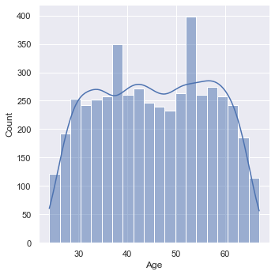

```python
sns.displot(df1["Age"], kde=True)
```

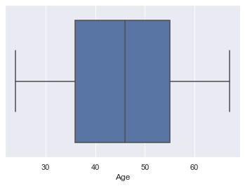

```python
sns.boxplot(df1["Age"]);
```

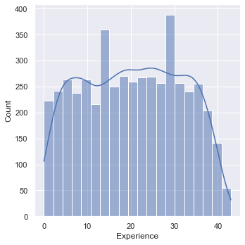

```python
sns.displot(df1["Experience"], kde=True);
```

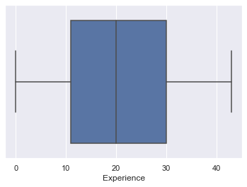

```python
sns.boxplot(df1["Experience"])
```

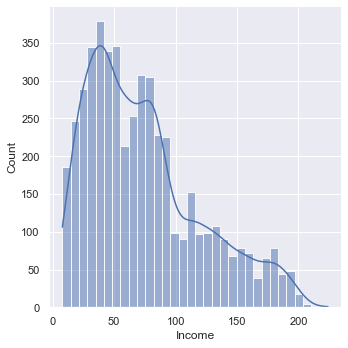

```python
sns.displot(df1["Income"], kde=True);
```

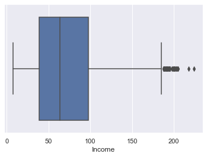

```python
sns.boxplot(df1["Income"])
```

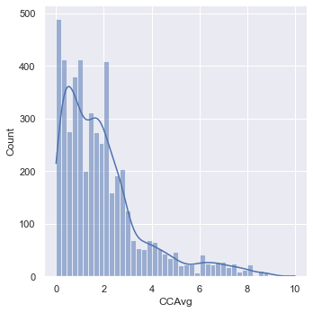

```python
sns.displot(df1["CCAvg"], kde=True);
```

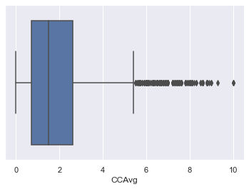

```python
sns.boxplot(df1["CCAvg"]);
```

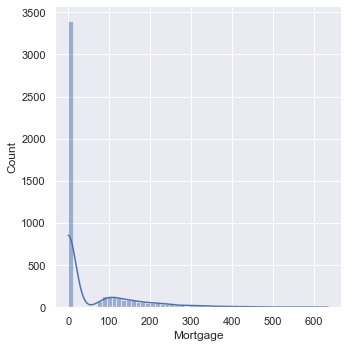

```python
sns.displot(df1["Mortgage"], kde=True);
```

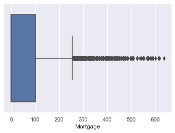

```python
sns.boxplot(df1["Mortgage"]);
```

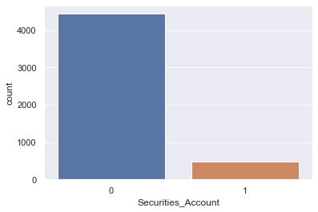

```python
plt.figure(figsize=(6,4))
sns.countplot(data=df1, x="Securities_Account")
plt.show()
```

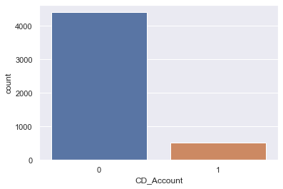

```python
plt.figure(figsize=(6,4))
sns.countplot(data=df1, x="CD_Account")
plt.show()
```

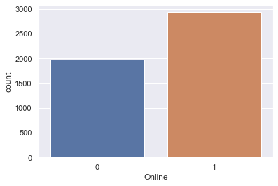

```python
plt.figure(figsize=(6,4))
sns.countplot(data=df1, x="Online")
plt.show()
```

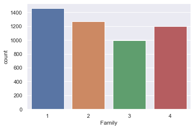

```python
plt.figure(figsize=(6,4))
sns.countplot(data=df1, x="Family")
plt.show()
```

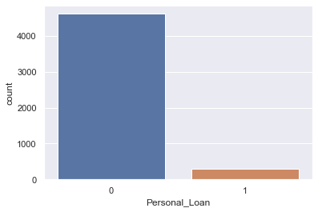

```python
plt.figure(figsize=(6,4))
sns.countplot(data=df1, x="Personal_Loan")
plt.show()
```

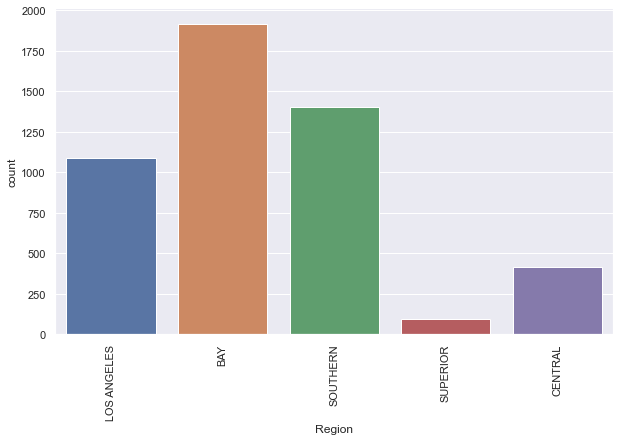

```python
plt.figure(figsize=(10,6))
sns.countplot(data=df1, x="Region")
plt.xticks(rotation=90)
plt.show()
```

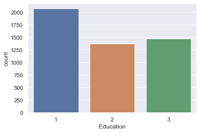

```python
plt.figure(figsize=(6,4))
sns.countplot(data=df1, x="Education")
```

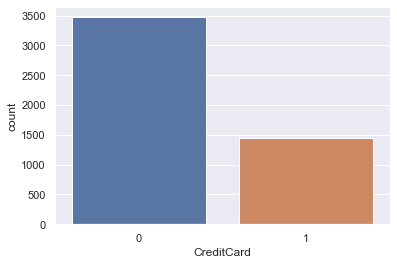

```python
plt.figure(figsize=(6,4))
sns.countplot(data=df1, x="CreditCard")
plt.show()
```

### Observation

1)Age is ranged 24 to 67, and there are no outliers in this variable. 2) 32 years of experience is more frequent, and 43 years of experience is least frequent. Sixty-six customers have 0 experience. Experience is ranged from 0 to 43 years. The box plot showed that there are no outliers in this variable. 3) Income is ranged widely, and there are some outliers. 4) The family size of 1 is most frequent than 2,3, or 4. 5) CCAvg is skewed right, and 0 value is most frequent, and there are outliers in this variable. 6) 0 is most frequent in the Mortgage column, and there are some outliers in this variable. 7) 0 value is more frequent in the Securities_Account, CD_Account, CreditCard, and Personal_Loan variables than 1 value. 8) Bay is the most frequent in the Region variable. 9) In Education, undergrad is the most frequent, and graduate is the least frequent value.

## Bivariate Analysis

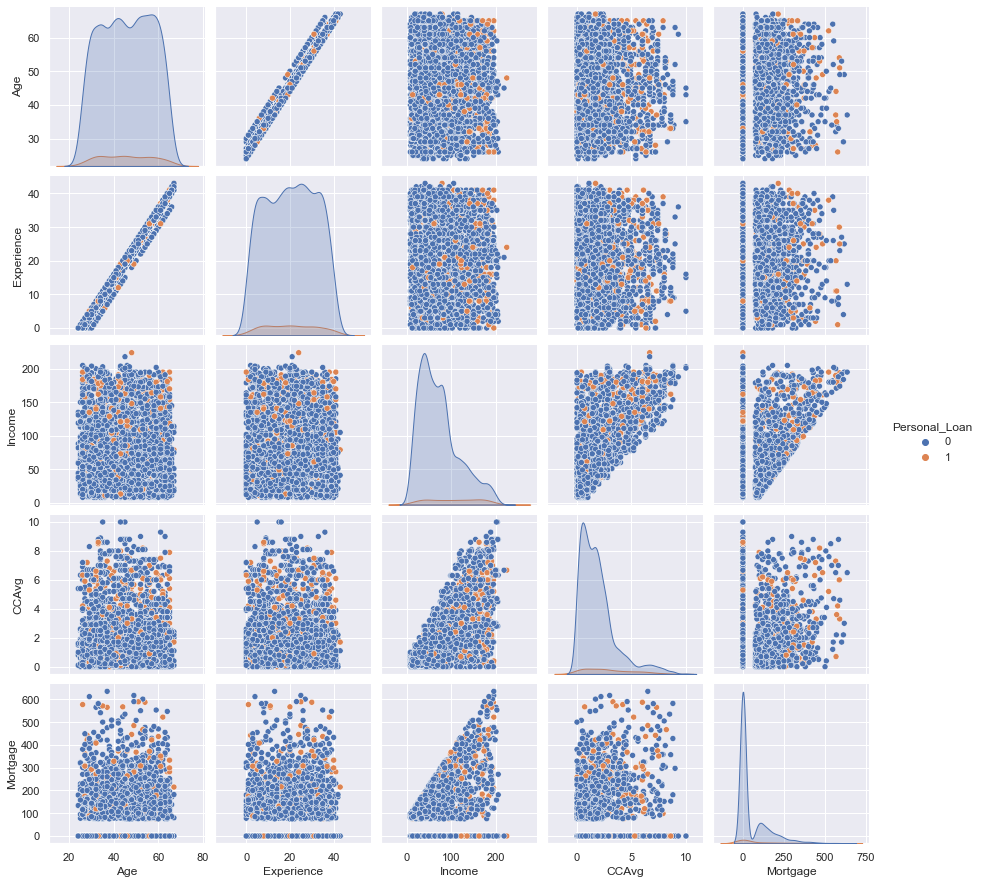

```python
sns.pairplot(df1, hue="Personal_Loan")
```

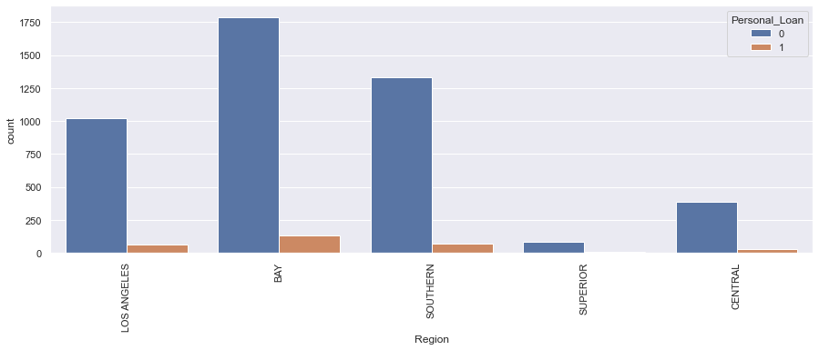

```python
plt.figure(figsize=(15,5))
sns.countplot(data=df1,x="Region", hue="Personal_Loan")
plt.xticks(rotation=90)
plt.show()
```

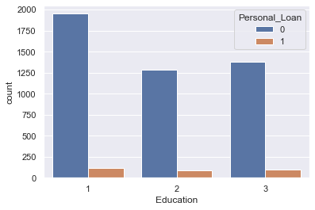

```python
plt.figure(figsize=(6,4))
sns.countplot(data=df1,x="Education", hue="Personal_Loan")
plt.show()
```

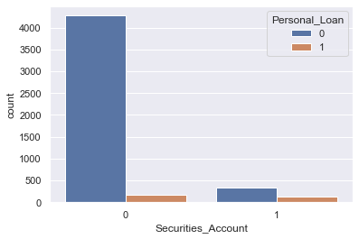

```python
plt.figure(figsize=(6,4))
sns.countplot(data=df1,x="Securities_Account", hue="Personal_Loan")
plt.show()
```

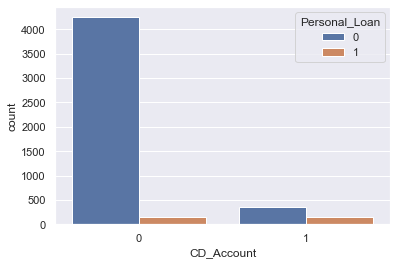

```python
plt.figure(figsize=(6,4))
sns.countplot(data=df1,x="CD_Account", hue="Personal_Loan")
plt.show()
```

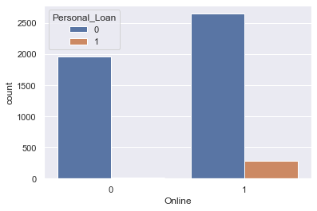

```python
plt.figure(figsize=(6,4))
sns.countplot(data=df1,x="Online", hue="Personal_Loan")
plt.show()
```

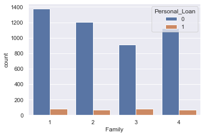

```python
plt.figure(figsize=(6,4))
sns.countplot(data=df1,x="Family", hue="Personal_Loan")
plt.show()
```

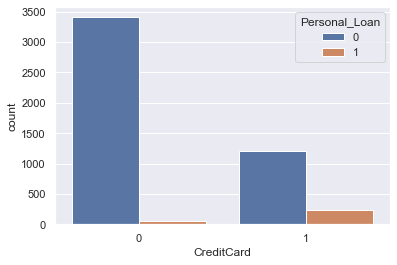

```python
plt.figure(figsize=(6,4))
sns.countplot(data=df1,x="CreditCard", hue="Personal_Loan")
plt.show()
```

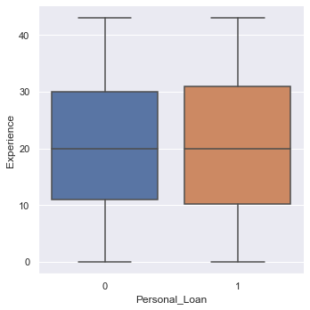

```python
plt.figure(figsize=(10,5))
sns.catplot(x="Personal_Loan", y="Experience", kind="box", data=df1)
plt.show()
```